# Migration Dynamics and Quality of Life Index

Welcome to our project page.

**Team BU-R-SEL**

[Selin DÜZEN](https://emu-hacettepe-analytics.github.io/emu660-spring2026-Selindznn/project.html)

[Burcu BARIŞ](https://emu-hacettepe-analytics.github.io/emu660-spring2026-burcubaris/project.html)

# 1. Project Overview and Scope

Migration is not merely the geographical displacement of individuals; it is also a reflection of economic pursuits, social opportunities, and structural quality in a region. In Turkey, the difference in development and living standards between provinces constitutes one of the primary dynamics of internal migration movements.

# 2. Data

## 2.1 Data Source

The datasets used in the project are:

1.Population size of the provinces

2.[Migration received by provinces according to the reason for migration](https://veriportali.tuik.gov.tr/api/tr/data/downloads?t=i&p=%2FMyiBh3DmS%2Bv%2BBjCf9%2BzPq%2B96lw8HZTF50uTl9jqBks%2BK5WE6sQNt%2Fqka0J5%2BImWGTGxKxiPcrz7kNG6I3rKkrLi%2B8mZkMkz9reke8%2BHd%2Fo%3D)

3.[Migration rates by provinces according to the reason for migration](https://veriportali.tuik.gov.tr/api/tr/data/downloads?t=i&p=%2FMyiBh3DmS%2Bv%2BBjCf9%2BzPq%2B96lw8HZTF50uTl9jqBks%2BK5WE6sQNt%2Fqka0J5%2BImWGTGxKxiPcrz7kNG6I3rKkrLi%2B8mZkMkz9reke8%2BHd%2Fo%3D)

4.[Net migration rate for provinces according to reasons for migration] Calculated as “Migration Outgoing - Migration Incoming”

5.[Life Index Rankings and Index Values by Province](https://www.sanayi.gov.tr/merkez-birimi/b94224510b7b/sege/il-sege-raporlari)

5 datasets were used in this study, plots were drawn and interpreted comprehensively.

## 2.2 General Information About Data

Our dataset tracks migration metrics across all 81 provinces of Türkiye from 2018 to 2024. It combines raw inbound/outbound migration figures with detailed columns explaining 12 different reasons for migration, cross-references them with the Livability/Prosperity Data, Since the Turkish Statistical Institute’s (TÜİK) “Provincial Livability Index” is only available up to 2015, data from the Ministry of Industry and Technology’s SEGE (Socio-Economic Development Index) has been used. The 2025 Provincial SEGE Report was used and shows the relationships between them.

## 2.3 Reason of Choice

We chose this data because migration cannot be explained solely by economic factors. By combining net migration metrics with the multidimensional Life Index (which assesses health, education, security, and environment), we can reveal the relationship between internal migration in Türkiye and life indices.

## 2.4 Preprocessing

The net migration values are calculated using migration data received and given by provinces in different Excel spreadsheets and the char formatted values containing spaces in the data were updated to numeric values.

```r
#install.packages("ggplot2")
#install.packages("dplyr")
#install.packages("openxlsx")
#install.packages("ggrepel")
library(ggplot2)
library(dplyr)
library(readxl)
library(writexl)
library(stringr)
library(forcats)
library(tidyr)
library(openxlsx)
library(ggplot2)
library(readxl)
library(dplyr)
library(ggrepel)
```

### 2.4.1. Calculating net migration values and creating a separate Excel file and checking and correcting numerical values.

In this section, we first performed data cleaning, and after cleaning, we applied the mathematical difference calculation to determine net migration. With `fark_df`, we can easily analyze which provinces have experienced net migration (if the result is positive, it means there has been outward migration) and which have received net migration (if the result is negative, it means there has been inward migration). There were invisible gaps in the TÜİK format data, and we cleaned all these gaps (\s) with `str_replace_all` and converted it to a numeric format (as.numeric). Net Migration Calculation: We created a new `fark_df` (Net Migration) matrix by subtracting the inward migration values from the given migration values and saved it as `NetGoc.xlsx`.

```r
VerilenGoc <- read_excel("C:/EMU660_Project/emu660-spring2026-Selindznn/VerilenGoc.xlsx", col_names = TRUE)
AlinanGoc  <- read_excel("C:/EMU660_Project/emu660-spring2026-Selindznn/AlinanGoc.xlsx", col_names = TRUE)
toplam_sutun <- ncol(VerilenGoc)
fark_df <- VerilenGoc
for (i in 3:toplam_sutun) {
  v_clean <- as.character(VerilenGoc[[i]])
  v_clean <- str_replace_all(v_clean, "\\s", "")
  VerilenGoc[[i]] <- as.numeric(v_clean)
  a_clean <- as.character(AlinanGoc[[i]])
  a_clean <- str_replace_all(a_clean, "\\s", "")
  AlinanGoc[[i]] <- as.numeric(a_clean)
}
fark_df[, 3:toplam_sutun] <- VerilenGoc[, 3:toplam_sutun] - AlinanGoc[, 3:toplam_sutun]
for (i in 3:toplam_sutun) {
  fark_df[[i]] <- as.numeric(fark_df[[i]])
}
write_xlsx(fark_df, "C:/EMU660_Project/emu660-spring2026-Selindznn/NetGoc.xlsx")
print(VerilenGoc[, 3:toplam_sutun])
```

```
# A tibble: 574 × 13
   `Toplam\r\nTotal` Tayin / iş değişikliği\r\nAssignat…¹ İşe başlamak /\r\n i…²
               <dbl>                                <dbl>                  <dbl>
 1           2682673                               280980                 221022
 2             56108                                 5251                   4260
 3             21158                                 2069                   1663
 4             25035                                 2770                   2657
 5             30970                                 4427                   2483
 6             14446                                 1594                   1444
 7            150373                                18554                  11161
 8             71999                                 5522                   5242
 9             10400                                 1046                   1110
10             35832                                 2971                   3561
# ℹ 564 more rows
# ℹ abbreviated names:
#   ¹`Tayin / iş değişikliği\r\nAssignation /\r\n change of job`,
#   ²`İşe başlamak /\r\n iş bulmak\r\nStarting / finding a job`
# ℹ 10 more variables: `Eğitim\r\nEducation` <dbl>,
#   `Medeni durum değişikliği / ailevi nedenler\r\nChange of marital status / family\r\nrelated reasons` <dbl>,
#   `Daha iyi konut ve yaşam koşulları\r\n Better housing and living conditions` <dbl>, …
```

### 2.4.2. Calculating net migration rate using population data of provinces and creating an Excel file.

```r
kaynak_yolu <- "C:/EMU660_Project/emu660-spring2026-Selindznn/NetGoc.xlsx"
hedef_yolu  <- "C:/EMU660_Project/emu660-spring2026-Selindznn/IlNufuslarii.xlsx"

df_kaynak <- read_excel(kaynak_yolu, col_names = TRUE)

NetGocVerisi <- df_kaynak[1:82, 3, drop = TRUE]
wb <- loadWorkbook(hedef_yolu)
writeData(wb, sheet = 1, x = "Net Göç", startCol = 3, startRow = 1, colNames = FALSE)
writeData(wb, sheet = 1, x = NetGocVerisi, startCol = 3, startRow = 2, colNames = FALSE)

saveWorkbook(wb, hedef_yolu, overwrite = TRUE)
```

# 3. Analysis

## 3.1 Exploratory Data Analysis

### 3.1.1. Changes in Total Migration Values by Year (2018-2024)

The changes in the total amount of migration over the years were shown graphically.

```r
grafik_verisi <- VerilenGoc[VerilenGoc[, 2] == "Toplam-Total", ]
print(grafik_verisi)
```

```
# A tibble: 7 × 15
  `Yıl\r\nYear` `İl\r\nProvince` `Toplam\r\nTotal` Tayin / iş değişikliği\r\nA…¹
          <dbl> <chr>                        <dbl>                         <dbl>
1          2024 Toplam-Total               2682673                        280980
2          2023 Toplam-Total               3450953                        320142
3          2022 Toplam-Total               2791156                        301335
4          2021 Toplam-Total               2777797                        265537
5          2020 Toplam-Total               2258726                        257027
6          2019 Toplam-Total               2806123                        262833
7          2018 Toplam-Total               3057606                        315849
# ℹ abbreviated name:
#   ¹`Tayin / iş değişikliği\r\nAssignation /\r\n change of job`
# ℹ 11 more variables:
#   `İşe başlamak /\r\n iş bulmak\r\nStarting / finding a job` <dbl>,
#   `Eğitim\r\nEducation` <dbl>,
#   `Medeni durum değişikliği / ailevi nedenler\r\nChange of marital status / family\r\nrelated reasons` <dbl>,
#   `Daha iyi konut ve yaşam koşulları\r\n Better housing and living conditions` <dbl>, …
```

```r
head(grafik_verisi)
```

```
# A tibble: 6 × 15
  `Yıl\r\nYear` `İl\r\nProvince` `Toplam\r\nTotal` Tayin / iş değişikliği\r\nA…¹
          <dbl> <chr>                        <dbl>                         <dbl>
1          2024 Toplam-Total               2682673                        280980
2          2023 Toplam-Total               3450953                        320142
3          2022 Toplam-Total               2791156                        301335
4          2021 Toplam-Total               2777797                        265537
5          2020 Toplam-Total               2258726                        257027
6          2019 Toplam-Total               2806123                        262833
# ℹ abbreviated name:
#   ¹`Tayin / iş değişikliği\r\nAssignation /\r\n change of job`
# ℹ 11 more variables:
#   `İşe başlamak /\r\n iş bulmak\r\nStarting / finding a job` <dbl>,
#   `Eğitim\r\nEducation` <dbl>,
#   `Medeni durum değişikliği / ailevi nedenler\r\nChange of marital status / family\r\nrelated reasons` <dbl>,
#   `Daha iyi konut ve yaşam koşulları\r\n Better housing and living conditions` <dbl>, …
```

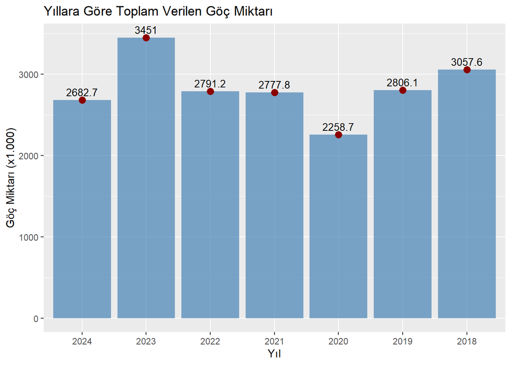

```r
yil <- factor(grafik_verisi[[1]], levels = sort(unique(grafik_verisi[[1]]), decreasing = TRUE))
goc_miktari  <- as.numeric(grafik_verisi[[3]])/1000

ggplot(data = grafik_verisi, aes(x = yil, y = goc_miktari)) +
  geom_col(fill = "steelblue", alpha = 0.7) +
  geom_line(color = "black", size = 2) +
  geom_point(color = "darkred", size = 3) +
  geom_text(aes(label = round(goc_miktari, 1)), vjust = -0.5, size = 3.5) +
  labs(
    title = "Yıllara Göre Toplam Verilen Göç Miktarı",
    x = "Yıl",
    y = "Göç Miktarı (x1.000)"
  )
```

### 3.1.2. Changes in Total Migration Values by Year for Ankara Provience

The graphic shows the changes in total migration amounts over the years for Ankara province.

```r
grafik_verisi <- VerilenGoc[VerilenGoc[, 2] == "Ankara", ]
print(grafik_verisi)
```

```
# A tibble: 7 × 15
  `Yıl\r\nYear` `İl\r\nProvince` `Toplam\r\nTotal` Tayin / iş değişikliği\r\nA…¹
          <dbl> <chr>                        <dbl>                         <dbl>
1          2024 Ankara                      150373                         18554
2          2023 Ankara                      208740                         21809
3          2022 Ankara                      161912                         18930
4          2021 Ankara                      165604                         19685
5          2020 Ankara                      141165                         19852
6          2019 Ankara                      154464                         18398
7          2018 Ankara                      221747                         24631
# ℹ abbreviated name:
#   ¹`Tayin / iş değişikliği\r\nAssignation /\r\n change of job`
# ℹ 11 more variables:
#   `İşe başlamak /\r\n iş bulmak\r\nStarting / finding a job` <dbl>,
#   `Eğitim\r\nEducation` <dbl>,
#   `Medeni durum değişikliği / ailevi nedenler\r\nChange of marital status / family\r\nrelated reasons` <dbl>,
#   `Daha iyi konut ve yaşam koşulları\r\n Better housing and living conditions` <dbl>, …
```

```r
head(grafik_verisi)
```

```
# A tibble: 6 × 15
  `Yıl\r\nYear` `İl\r\nProvince` `Toplam\r\nTotal` Tayin / iş değişikliği\r\nA…¹
          <dbl> <chr>                        <dbl>                         <dbl>
1          2024 Ankara                      150373                         18554
2          2023 Ankara                      208740                         21809
3          2022 Ankara                      161912                         18930
4          2021 Ankara                      165604                         19685
5          2020 Ankara                      141165                         19852
6          2019 Ankara                      154464                         18398
# ℹ abbreviated name:
#   ¹`Tayin / iş değişikliği\r\nAssignation /\r\n change of job`
# ℹ 11 more variables:
#   `İşe başlamak /\r\n iş bulmak\r\nStarting / finding a job` <dbl>,
#   `Eğitim\r\nEducation` <dbl>,
#   `Medeni durum değişikliği / ailevi nedenler\r\nChange of marital status / family\r\nrelated reasons` <dbl>,
#   `Daha iyi konut ve yaşam koşulları\r\n Better housing and living conditions` <dbl>, …
```

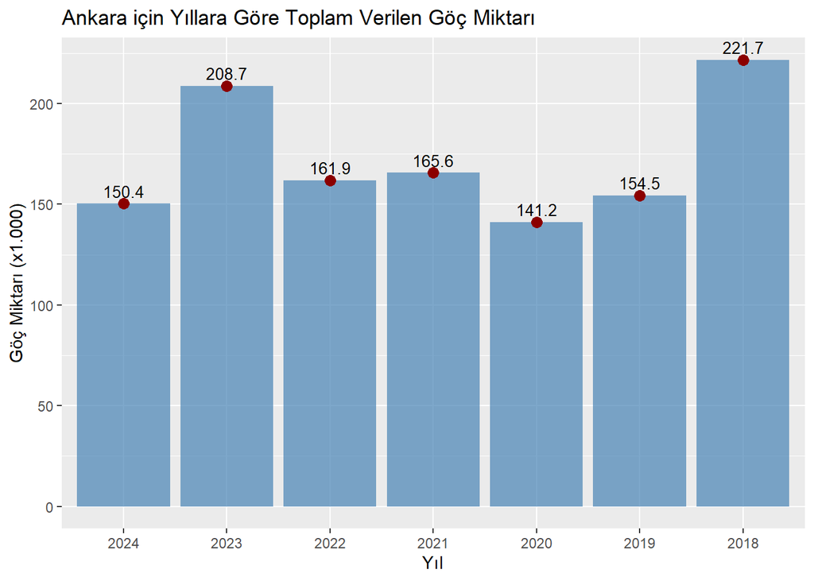

```r
yil <- factor(grafik_verisi[[1]], levels = sort(unique(grafik_verisi[[1]]), decreasing = TRUE))
goc_miktari  <- as.numeric(grafik_verisi[[3]])/1000

ggplot(data = grafik_verisi, aes(x = yil, y = goc_miktari)) +
  geom_col(fill = "steelblue", alpha = 0.7) +
  geom_line(color = "black", size = 2) +
  geom_point(color = "darkred", size = 3) +
  geom_text(aes(label = round(goc_miktari, 1)), vjust = -0.5, size = 3.5) +
  labs(
    title = "Ankara için Yıllara Göre Toplam Verilen Göç Miktarı",
    x = "Yıl",
    y = "Göç Miktarı (x1.000)"
  )
```

### 3.1.3. Migration Figures by Province in 2024

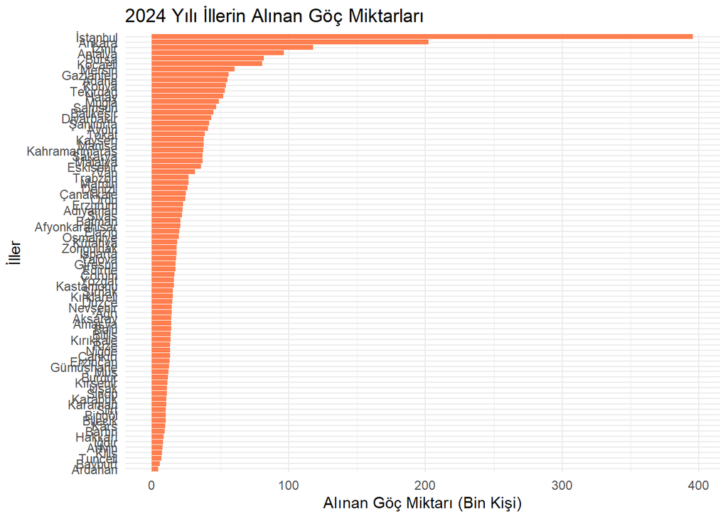

```r
AlinanGoc  <- read_excel("C:/EMU660_Project/emu660-spring2026-Selindznn/AlinanGoc.xlsx",col_names = TRUE)

colnames(AlinanGoc)[1:3] <- c("Yil", "Il", "Goc_Miktari")
veri_2024 <- subset(AlinanGoc, Yil == 2024 & Il != "Toplam-Total")
veri_2024$Goc_Miktari_Bin <- veri_2024$Goc_Miktari / 1000


ggplot(veri_2024, aes(x = Goc_Miktari_Bin, y = reorder(Il, Goc_Miktari_Bin))) +
  geom_col(aes(fill = Goc_Miktari_Bin > 0)) +
  scale_fill_manual(values = c("coral", "skyblue"), guide = "none") +
  theme_minimal() +
  labs(
    title = "2024 Yılı İllerin Alınan Göç Miktarları",
    x = "Alınan Göç Miktarı (Bin Kişi)",
    y = "İller"
  )
```

### 3.1.4. Net Migration Figures of Provinces in 2024

A graphical representation of the calculation made using the previously calculated data given migration-received migration data.

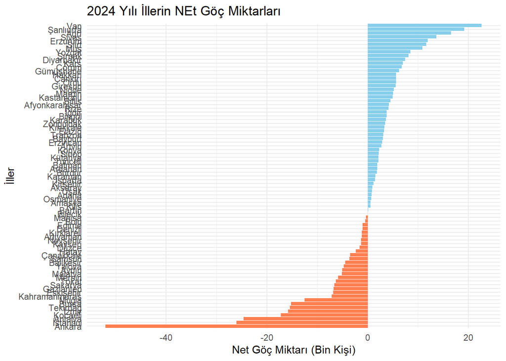

```r
NetGoc  <- read_excel("C:/EMU660_Project/emu660-spring2026-Selindznn/NetGoc.xlsx",col_names = TRUE)

colnames(NetGoc)[1:3] <- c("Yil", "Il", "Goc_Miktari")
veri_2024 <- subset(NetGoc, Yil == 2024 & Il != "Toplam-Total")
veri_2024$Goc_Miktari_Bin <- veri_2024$Goc_Miktari / 1000


ggplot(veri_2024, aes(x = Goc_Miktari_Bin, y = reorder(Il, Goc_Miktari_Bin))) +
  geom_col(aes(fill = Goc_Miktari_Bin > 0)) +
  scale_fill_manual(values = c("coral", "skyblue"), guide = "none") +
  theme_minimal() +
  labs(
    title = "2024 Yılı İllerin NEt Göç Miktarları",
    x = "Net Göç Miktarı (Bin Kişi)",
    y = "İller"
  )
```

### 3.1.5. Graph showing the distribution of migration reasons that make up net migration data.

Migration reasons include: change of job, starting/finding a job, change of marital status/family-related reasons, better housing and living conditions, migration related to any member of the household/family, returning to family home/hometown, health/care, buying a house, retirement, other, and unknown.

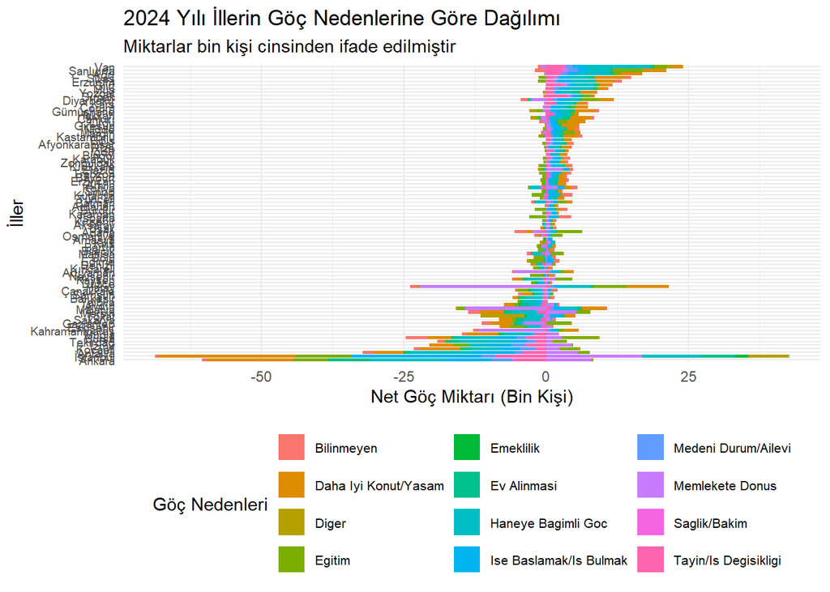

```r
NetGoc  <- read_excel("C:/EMU660_Project/emu660-spring2026-Selindznn/NetGoc.xlsx",col_names = TRUE)

goc_nedenleri <- c("Tayin/Is Degisikligi", "Ise Baslamak/Is Bulmak", "Egitim",
                   "Medeni Durum/Ailevi", "Daha Iyi Konut/Yasam", "Haneye Bagimli Goc",
                   "Memlekete Donus", "Saglik/Bakim", "Ev Alinmasi",
                   "Emeklilik", "Diger", "Bilinmeyen")

colnames(NetGoc)[1:3] <- c("Yil", "Il", "Toplam_Goc")
colnames(NetGoc)[4:15] <- goc_nedenleri
veri_2024 <- subset(NetGoc, Yil == 2024 & Il != "Toplam-Total")

veri_uzun <- pivot_longer(veri_2024,
                          cols = 4:15,
                          names_to = "Goc_Nedeni",
                          values_to = "Miktar")

veri_uzun$Miktar_Bin <- veri_uzun$Miktar / 1000

goc_grafigi <- ggplot(veri_uzun, aes(x = Miktar_Bin, y = reorder(Il, Toplam_Goc), fill = Goc_Nedeni)) +
  geom_col(position = "stack") +
  theme_minimal() +
  labs(
    title = "2024 Yılı İllerin Göç Nedenlerine Göre Dağılımı",
    subtitle = "Miktarlar bin kişi cinsinden ifade edilmiştir",
    x = "Net Göç Miktarı (Bin Kişi)",
    y = "İller",
    fill = "Göç Nedenleri"
  ) +
  theme(
    legend.position = "bottom",
    legend.text = element_text(size = 8),
    axis.text.y = element_text(size = 7)
  ) +
  guides(fill = guide_legend(ncol = 3))

print(goc_grafigi)
```

## 3.2 Trend Analysis

The graph shows the relational analysis between migration rate data and life indices of the provinces.

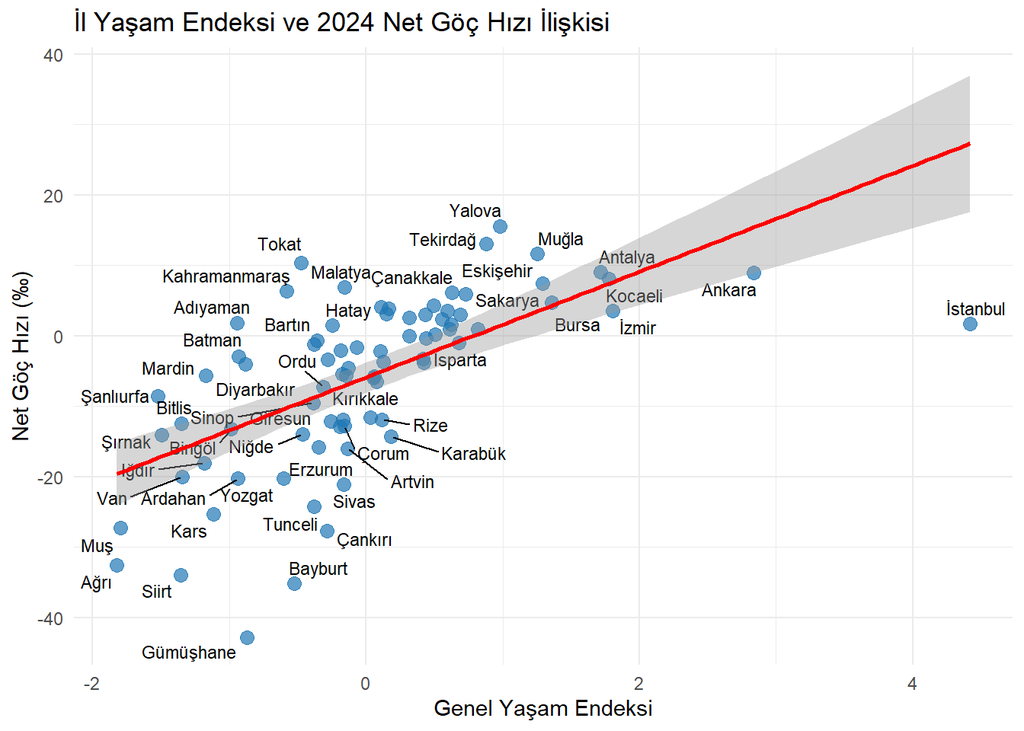

```r
yasam_df <- read_excel("C:/EMU660_Project/emu660-spring2026-Selindznn/YasamEndeksi.xlsx", col_names = TRUE)
goc_df <- read_excel("C:/EMU660_Project/emu660-spring2026-Selindznn/Gochizi.xlsx", col_names = TRUE)

colnames(yasam_df)[1:2] <- c("Il", "Endeks")
colnames(goc_df)[1:3]   <- c("Yil", "Il", "Goc")

goc_2024 <- subset(goc_df, Yil == 2024 & Il != "Toplam-Total")

veri_seti <- inner_join(yasam_df, goc_2024, by = "Il")

grafik <- ggplot(veri_seti, aes(x = Endeks, y = Goc, label = Il)) +
  geom_point(color = "#1f77b4", size = 3, alpha = 0.7) +
  geom_text_repel(size = 3, max.overlaps = 15) +
  geom_smooth(method = "lm", color = "red", se = TRUE, formula = y ~ x) +
  labs(
    title = "İl Yaşam Endeksi ve 2024 Net Göç Hızı İlişkisi",
    x = "Genel Yaşam Endeksi",
    y = "Net Göç Hızı (‰)"
  ) +
  theme_minimal()

print(grafik)
```

## 3.4 Results

Our time series analysis (2018–2024) shows that overall migration numbers fluctuate significantly based on national economic shifts and major external events (e.g., pandemics, earthquakes). When we looking at major metropolitan areas like Ankara, we see a distinct pattern of high incoming and high outgoing figures, reflecting its status as a dynamic political and educational hub. Our 2024 province-by-province breakdown confirms that the geographic distribution of migration in Turkey is highly polarized. A small cluster of economically dominant provinces acts as “Net Migration Champions,” while a vast majority of eastern and rural provinces serve as continuous “Migration Sources. The stacked column chart for 2024 reasons for migration provides crucial insights. Rather than simple employment changes (”Tayin/İş Değişikliği”), a massive portion of net migration is driven by:Education (“Eğitim”): Causing heavy youth mobility toward university cities.Better Housing and Living Conditions (“Daha İyi Konut/Yaşam”) Indicating that families are moving reactively to secure better urban standards.Dependent Migration (“Haneye Bağımlı Göç”)Showing that migration is rarely an individual choice but a household-level transition. Our trend analysis using geom_smooth(method = “lm”) reveals a positive correlation between a province’s General Life Index and its Net Migration Rate.

# 4. Results and Key Takeaways

Governments should focus on raising the localized “Life Index” components—such as building better hospitals, upgrading schools, and enhancing civic safety in negative-net-migration provinces—to encourage citizens to stay.

Back to top